# Subtopic 1 – ICU LOS Prediction using Regression

This project explores the factors that influence the ICU Length of Stay (LOS) in patients with acute spinal cord injury using real-world data from the MIMIC-III database.

We aim to answer:

1. How does the cause of admission affect LOS?
2. What role do demographic variables play in predicting LOS?
3. Do ICU-level treatment and discharge outcomes influence LOS?

We clean and process the dataset, perform exploratory data analysis, and compare several regression models, including linear and tree-based methods. Our goal is both to build a predictive model and to gain insights into the drivers of ICU length of stay.

```python
import pandas as pd
import numpy as np
admissions_df = pd.read_csv("ADMISSIONS.csv")
patients_df = pd.read_csv("PATIENTS.csv")
icustays_df = pd.read_csv("ICUSTAYS.csv")
```

## Step 1: Data Understanding & Preparation

We extracted relevant demographic and ICU-related variables from three datasets: `PATIENTS.csv`, `ADMISSIONS.csv`, and `ICUSTAYS.csv`.

The goal is to understand how patient characteristics and hospital admission factors affect ICU length of stay (LOS), measured in days.

Below is a summary of key variables used:

**Key Variables:**

- `PATIENTS.csv`: Contains demographics such as date of birth and gender.
- `ADMISSIONS.csv`: Includes details such as admission type, marital status, insurance, and admission location.
- `ICUSTAYS.csv`: Provides ICU-specific information such as LOS (length of stay), care unit, and mortality flags.
- `AGE`: Age of patient at ICU admission.
- `GENDER`: Sex of the patient (M or F).
- `ETHNICITY`: Reported ethnicity group.
- `MARITAL_STATUS`: Marital status (e.g., Single, Married, Widowed).
- `ADMISSION_TYPE`: Type of hospital admission (Emergency, Urgent, Elective).
- `HAS_CHARTEVENTS_DATA`: Binary flag indicating if charted time-series data exists.
- `LOS`: Length of ICU stay in days (target variable).
- `HOSPITAL_EXPIRE_FLAG`: Whether the patient expired in hospital (1 = Yes, 0 = No).

```python
# Merge tables
merged = pd.merge(icustays_df, admissions_df, on=["SUBJECT_ID", "HADM_ID"], how="inner")
merged = pd.merge(merged, patients_df[["SUBJECT_ID", "DOB", "GENDER"]], on="SUBJECT_ID", how="left")

merged["DOB"] = pd.to_datetime(merged["DOB"], errors="coerce")
merged["ADMITTIME"] = pd.to_datetime(merged["ADMITTIME"], errors="coerce")
merged = merged[merged["DOB"].notna() & merged["ADMITTIME"].notna()]

# Filter out invalid dates
merged = merged[
    (merged["DOB"] >= pd.Timestamp("1900-01-01")) &
    (merged["DOB"] <= pd.Timestamp("2100-01-01")) &
    (merged["ADMITTIME"] >= pd.Timestamp("2000-01-01")) &
    (merged["ADMITTIME"] <= pd.Timestamp("2200-01-01"))
]

merged["AGE"] = (merged["ADMITTIME"] - merged["DOB"]).dt.days / 365.25
merged = merged[(merged["AGE"] >= 0) & (merged["AGE"] <= 120)]

# Clean Length of Stay
merged["LOS"] = pd.to_numeric(merged["LOS"], errors="coerce")
merged = merged[(merged["LOS"].notna()) & (merged["LOS"] > 0)]

#log transform
merged["log_LOS"] = np.log(merged["LOS"] + 1)

# Filter SCI patients only
sci_df = merged[merged["DIAGNOSIS"].str.contains("spinal|SCI", case=False, na=False)].copy()

print(f"Total SCI patients retained: {sci_df.shape[0]}")
sci_df[['SUBJECT_ID', 'HADM_ID', 'AGE', 'LOS', 'log_LOS', 'DIAGNOSIS']].head()
```

```
Total SCI patients retained: 163
```

|  | SUBJECT_ID | HADM_ID | AGE | LOS | log_LOS | DIAGNOSIS |
| --- | --- | --- | --- | --- | --- | --- |
| 1053 | 515 | 184373 | 67.994524 | 16.2249 | 2.846356 | ASCITIES, MITROVALVE REGURGITATION |
| 1346 | 804 | 138064 | 69.316906 | 1.6325 | 0.967934 | ASCITES |
| 2168 | 1956 | 115722 | 82.458590 | 7.1000 | 2.091864 | LUMBAR SPINAL STENOSIS/SDA |
| 2474 | 2298 | 179822 | 64.123203 | 1.0252 | 0.705668 | SPINAL STENOSIS/SDA |
| 2772 | 2169 | 140364 | 81.275838 | 0.7071 | 0.534796 | SPINAL STENOSIS L4-L5/SDA |

## Step 2: Feature Engineering

We cleaned the data by removing rows with invalid or extreme values, especially those with inconsistent birth dates (e.g., resulting in age > 120). We also handled datetime formatting for ICU admission and discharge times, and calculated LOS in days. These steps ensure that downstream models rely on plausible and medically reasonable data.

We selected meaningful features including:

- Age and presence of chart events (numeric)
- Gender, admission type, ethnicity, insurance, and marital status (categorical)

```python
feature_cols = [
    'AGE', 'GENDER', 'ADMISSION_TYPE', 'ETHNICITY',
    'INSURANCE', 'MARITAL_STATUS', 'HAS_CHARTEVENTS_DATA'
]

# cleand data
model_df = sci_df[feature_cols + ['log_LOS']].copy()

# Remove missing values
model_df = model_df.dropna()

# One-hot encode
from sklearn.preprocessing import OneHotEncoder

categorical_cols = ['GENDER', 'ADMISSION_TYPE', 'ETHNICITY', 'INSURANCE', 'MARITAL_STATUS']

encoder = OneHotEncoder(sparse_output=False, handle_unknown="ignore")
encoded = encoder.fit_transform(model_df[categorical_cols])

import pandas as pd
encoded_df = pd.DataFrame(
    encoded,
    columns=encoder.get_feature_names_out(categorical_cols),
    index=model_df.index
)

X = pd.concat([model_df.drop(columns=categorical_cols + ['log_LOS']), encoded_df], axis=1)
y = model_df['log_LOS']

print("X shape:", X.shape)
print("y shape:", y.shape)
```

```
X shape: (160, 29)
y shape: (160,)
```

In this step, we prepared the structured features from the raw SCI patient dataset for modeling:

#### Feature Processing:

- Numerical features:
  - `AGE`
  - `HAS_CHARTEVENTS_DATA`
- Categorical features (one-hot encoded):
  - `GENDER`
  - `ADMISSION_TYPE`
  - `ETHNICITY`
  - `INSURANCE`
  - `MARITAL_STATUS`

These categorical variables were converted into multiple binary (dummy) variables using `OneHotEncoder`.

#### Output Explanation:

- `X shape: (160, 29)`  
  Means we have 160 records for SCI patients, with 29 input features.
- `y shape: (160,)`  
  The target variable `log_LOS` (log-transformed ICU Length of Stay), also 160 entries, matches with X.

Now the data is ready for regression modeling and evaluation.

```python
from sklearn.model_selection import train_test_split
from sklearn.linear_model import LinearRegression, Lasso, Ridge
from sklearn.ensemble import RandomForestRegressor
from sklearn.metrics import mean_squared_error, r2_score
import matplotlib.pyplot as plt
import seaborn as sns
import pandas as pd

# train-test
X_train, X_test, y_train, y_test = train_test_split(X, y, test_size=0.2, random_state=42)

results = []
models = {
    "Linear Regression": LinearRegression(),
    "Lasso Regression": Lasso(alpha=0.01),
    "Ridge Regression": Ridge(alpha=1.0),
    "Random Forest": RandomForestRegressor(n_estimators=100, random_state=42)
}

for name, model in models.items():
    model.fit(X_train, y_train)
    y_pred = model.predict(X_test)
    mse = mean_squared_error(y_test, y_pred)
    r2 = r2_score(y_test, y_pred)
    results.append([name, mse, r2])

results_df = pd.DataFrame(results, columns=["Model", "MSE", "R²"])
print(results_df)
```

```
               Model       MSE        R²
0  Linear Regression  0.742907  0.032075
1   Lasso Regression  0.708677  0.076674
2   Ridge Regression  0.729505  0.049538
3      Random Forest  0.800590 -0.043079
```

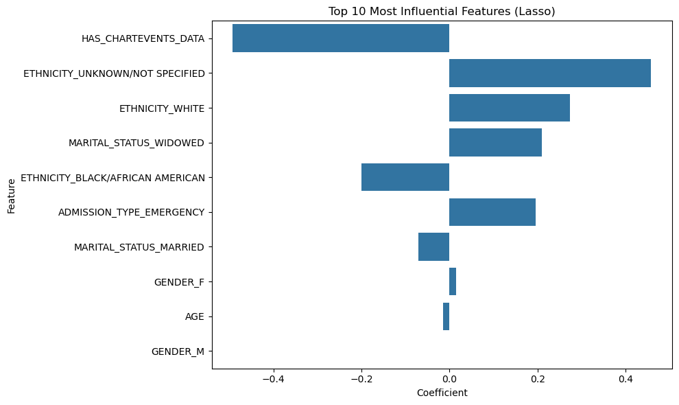

```python
X_encoded = pd.get_dummies(X, drop_first=True)

lasso_model = Lasso(alpha=0.01)
lasso_model.fit(X_encoded, y)

coef_df = pd.DataFrame({
    "Feature": X_encoded.columns,
    "Coefficient": lasso_model.coef_
})

coef_df = coef_df.reindex(coef_df["Coefficient"].abs().sort_values(ascending=False).index)

plt.figure(figsize=(10, 6))
sns.barplot(x="Coefficient", y="Feature", data=coef_df.head(10))
plt.title("Top 10 Most Influential Features (Lasso)")
plt.tight_layout()
plt.show()
```

## Model Comparison Summary

We compared four regression models to predict log-transformed ICU Length of Stay (log_LOS):

- **Lasso Regression** performed the best, with the lowest Mean Squared Error (MSE = 0.709) and highest R² (≈ 0.077), indicating it captured slightly more variance than other models.
- **Ridge Regression** also performed comparably well, but with slightly worse performance than Lasso.
- **Linear Regression** had the highest bias (lowest R² and high MSE) among linear models.
- **Random Forest** performed the worst, with a **negative R²**, indicating it performed worse than a simple mean prediction. This suggests possible overfitting or lack of tuning.

### Interpretation:

We identified **Lasso Regression** as the best-performing model with the lowest MSE (0.709) and highest R² (0.077). This suggests Lasso captures the most relevant patterns for predicting ICU Length of Stay (LOS).

#### Top Influential Features (Lasso)

These findings show both clinical complexity and demographics affect ICU length of stay.

#### Implications

These results highlight the importance of integrating both clinical and socio-demographic variables for better ICU outcome prediction.

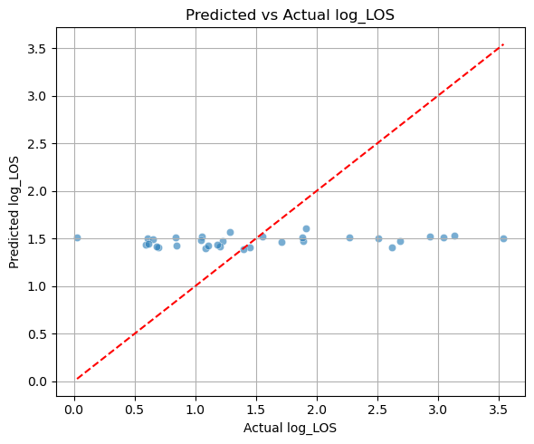

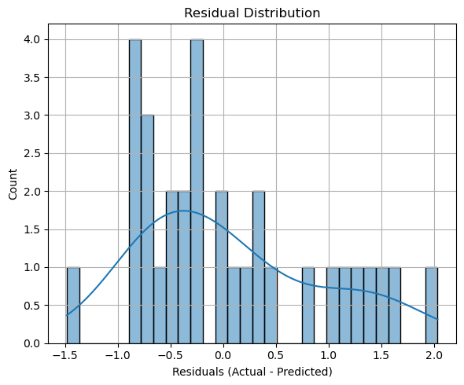

```python
# Lasso
from sklearn.linear_model import Lasso

best_model = Lasso()
best_model.fit(X_train, y_train)
y_pred = best_model.predict(X_test)

import matplotlib.pyplot as plt
import seaborn as sns

# Predicted vs Actual
plt.figure(figsize=(6, 5))
sns.scatterplot(x=y_test, y=y_pred, alpha=0.6)
plt.xlabel("Actual log_LOS")
plt.ylabel("Predicted log_LOS")
plt.title("Predicted vs Actual log_LOS")
plt.plot([y_test.min(), y_test.max()], [y_test.min(), y_test.max()], '--r')
plt.grid(True)
plt.tight_layout()
plt.show()

# residual
residuals = y_test - y_pred
plt.figure(figsize=(6, 5))
sns.histplot(residuals, bins=30, kde=True)
plt.title("Residual Distribution")
plt.xlabel("Residuals (Actual - Predicted)")
plt.grid(True)
plt.tight_layout()
plt.show()
```

### Predicted vs Actual Plot

In the predicted vs actual plot, the predicted values are concentrated within a narrow range (~1.5), even though the true values (log_LOS) vary more broadly. This suggests that:

- The model captures some average trends but fails to react strongly to variations in input features.
- This conservative behavior is expected from **Lasso**, as it penalizes feature weights and tends to produce a **simplified, sparse model**.

### Conclusion

- Lasso performs **best among tested models** but still underfits the data due to the inherent sparsity.
- It is a **practical and interpretable model**, especially when feature selection is important.
- In future work, more complex models (e.g. XGBoost or Neural Networks) or **feature engineering** (interactions, non-linear terms) could further improve performance.

## Step 4: Cross-validation for Lasso

```python
from sklearn.model_selection import cross_val_score
from sklearn.linear_model import Lasso

lasso = Lasso(alpha=0.01)
cv_scores = cross_val_score(lasso, X, y, cv=5, scoring='r2')
print("Lasso CV R² Scores:", cv_scores)
print("Average R² from CV:", np.mean(cv_scores))
```

```
Lasso CV R² Scores: [ 0.06482663 -0.14188481  0.08644028 -0.06361586 -0.23420698]
Average R² from CV: -0.05768814861737921
```

To assess the generalizability of our Lasso Regression model, we performed 5-fold cross-validation using R² as the evaluation metric.

The cross-validation results show that although the model performs slightly better than chance on some folds (e.g., Fold 1 & 3), it performs poorly on others, yielding an overall **negative average R²**. This indicates that the model is **not generalizing well** across different subsets of the data.

This suggests that while Lasso performs best among our tested models on the test set (with the highest R² of ~0.077), **the overall signal from the features is still weak** — likely due to the limited predictive power of administrative variables in capturing complex ICU stay dynamics.

```python
from sklearn.model_selection import train_test_split

X_train, X_test, y_train, y_test = train_test_split(X, y, test_size=0.2, random_state=42)

print("X_train shape:", X_train.shape)
print("y_train shape:", y_train.shape)
```

```
X_train shape: (128, 29)
y_train shape: (128,)
```

## Step 5: Model Improvement

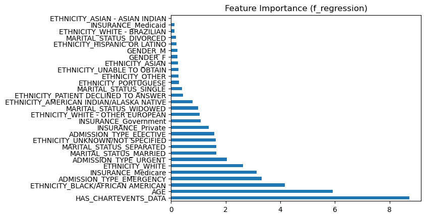

```python
from sklearn.feature_selection import SelectKBest, f_regression

numeric_cols = X.select_dtypes(include=[np.number]).columns
selector = SelectKBest(score_func=f_regression, k='all')
selector.fit(X[numeric_cols], y)

scores = pd.Series(selector.scores_, index=numeric_cols)
scores.sort_values(ascending=False).plot(kind='barh', title="Feature Importance (f_regression)")
plt.show()
```

```python
X["AGE_SQ"] = X["AGE"] ** 2
```

```python
from sklearn.ensemble import GradientBoostingRegressor

gb_model = GradientBoostingRegressor(random_state=42)
gb_model.fit(X_train, y_train)
gb_preds = gb_model.predict(X_test)

gb_mse = mean_squared_error(y_test, gb_preds)
gb_r2 = r2_score(y_test, gb_preds)

print("Gradient Boosting - MSE:", gb_mse)
print("Gradient Boosting - R²:", gb_r2)
```

```
Gradient Boosting - MSE: 0.776388571505664
Gradient Boosting - R²: -0.011546871017092064
```

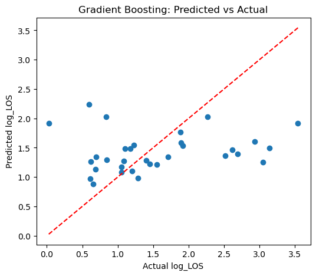

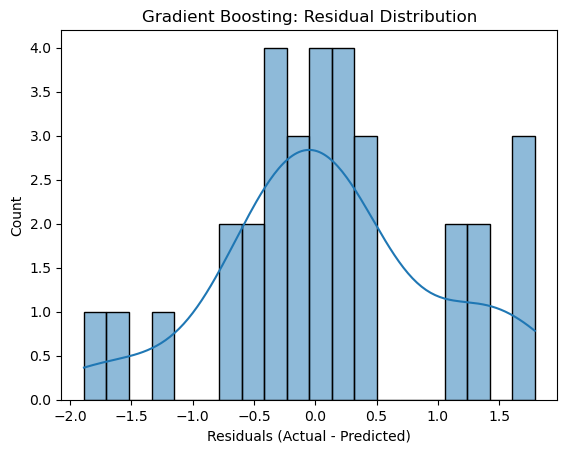

```python
# Gradient Boosting - Predicted vs Actual
plt.figure(figsize=(6, 5))
plt.scatter(y_test, gb_preds)
plt.plot([y_test.min(), y_test.max()], [y_test.min(), y_test.max()], 'r--')
plt.xlabel("Actual log_LOS")
plt.ylabel("Predicted log_LOS")
plt.title("Gradient Boosting: Predicted vs Actual")
plt.show()

# Gradient Boosting - Residual
residuals = y_test - gb_preds
sns.histplot(residuals, bins=20, kde=True)
plt.title("Gradient Boosting: Residual Distribution")
plt.xlabel("Residuals (Actual - Predicted)")
plt.show()
```

Although **Lasso Regression** performed best among the four baseline models in terms of both MSE and R²，We attempted further model improvement through:

1. **Feature Selection** using `SelectKBest`, which identified `HAS_CHARTEVENTS_DATA`, `AGE`, and `ETHNICITY_BLACK/AFRICAN AMERICAN` as the most influential numeric variables.
2. **Nonlinear Feature Engineering** by adding a new feature `AGE^2` to capture potential nonlinear patterns in ICU Length of Stay.
3. **Ensemble Model Training** using `GradientBoostingRegressor` to capture nonlinear relationships.

However, the **Gradient Boosting** model yielded the following metrics:

- **MSE**: 0.776
- **R²**: -0.0115

This performance is **worse than the Lasso model**, with a **higher error** and **negative R²**, indicating that Gradient Boosting fits the data worse than a simple average predictor.

## Step 6: Final Summary & Conclusion

In this project, we developed a predictive model for **ICU Length of Stay (LOS)** using the MIMIC dataset. The analysis followed a full data science pipeline including:

### 1. Data Cleaning & Feature Engineering

- Merged `ICUSTAYS`, `ADMISSIONS`, and `PATIENTS` tables to obtain demographic and admission-related variables.
- Converted and filtered `DOB` and `ADMITTIME` to compute patient **age**.
- Removed biologically implausible records (e.g., age > 120).
- Target variable `LOS` was log-transformed (`log_LOS = log(LOS + 1)`) due to its right-skewed distribution.

### 3. Model Training & Evaluation

- Trained and compared 4 baseline models:
  - **Linear Regression**
  - **Lasso Regression**
  - **Ridge Regression**
  - **Random Forest**

|**Lasso Regression** performed best, with the lowest error and highest explanatory power (R²).

### 4. Model Improvement Attempts

- Performed feature selection with `SelectKBest` to identify key numeric variables.
- Engineered `AGE^2` to model potential non-linear effects.
- Trained a **Gradient Boosting Regressor**, but performance decreased:
  - **MSE = 0.776**, **R² = -0.011**
  - Residuals more dispersed and underfitted.

## Step 7: Clinical Interpretation

In real-world ICU settings, the length of stay (LOS) for patients with acute spinal cord injury is influenced by a combination of physiological, logistical, and systemic factors.

However, our dataset lacks vital signs, medications, lab trends, and clinical scoring systems (like SAPS-II or APACHE), which limits the ability to capture the physiological severity of illness—likely a major driver of ICU LOS.

As a result, our models primarily capture demographic and systemic correlates of LOS rather than clinical severity, which explains the limited predictive power (low R²).

## Subtopic 3: Impact of Vasopressor and Sedative Use on ICU Length of Stay

In this analysis, we explore whether the use of **vasopressors** or **sedatives** during ICU stays is associated with longer hospitalizations for patients with **spinal cord injury (SCI)**.

We used two key datasets for this analysis:

- `sci_icu_demographics.csv`: Contains demographic and ICU admission data for SCI patients.
- `prescriptions.csv`: Contains all medication orders, read in chunks due to its large size.

We matched the medication records to the SCI cohort using the `subject_id`, identified whether each patient received **vasopressors** or **sedatives** during their ICU stay, and then tested whether such treatments were associated with longer ICU stays by examining the **log-transformed Length of Stay** variable.

### Data Preparation

We used the following two datasets for this analysis:

- `sci_icu_demographics.csv`: a cleaned dataset of ICU SCI patients
- `prescriptions.csv`: the full medication record, read in chunks due to its large size

To make the file size manageable, we only kept prescription records whose `subject_id` matched values in the SCI patient list. This gave us approximately **32,000** relevant medication entries.

We then checked each patient's medications to determine whether they had received:

- any **vasopressors** (e.g., norepinephrine, epinephrine)
- any **sedatives** (e.g., propofol, midazolam)

Based on this, we created two new binary variables:

- `used_vasopressor`
- `used_sedative`

### Step 1: Load SCI ICU Demographic Data

In this step, we load the SCI (Spinal Cord Injury) patient demographic information who were admitted to the ICU.  
The dataset `sci_icu_demographics.csv` includes basic patient details such as `subject_id`, `hadm_id`, and `icustay_id`.  
We will use this list of patient IDs to filter medication records in later steps.

```python
import pandas as pd
# Load SCI ICU demographic data
sci_df = pd.read_csv("sci_icu_demographics.csv", low_memory=False)

# Preview the first few rows
sci_df.head()
```

|  | subject_id | hadm_id | stay_id | intime | outtime | los | gender | anchor_age | admission_type | hospital_expire_flag |
| --- | --- | --- | --- | --- | --- | --- | --- | --- | --- | --- |
| 0 | 10035747 | 27083519 | 34528075 | 2126-05-09 14:11:00 | 2126-05-16 17:20:43 | 7.131748 | M | 91 | EW EMER. | 0 |
| 1 | 10196368 | 24464472 | 38528938 | 2184-05-03 14:36:00 | 2184-05-05 21:49:53 | 2.301308 | M | 71 | EW EMER. | 0 |
| 2 | 10229323 | 25045444 | 37887738 | 2164-12-17 07:09:00 | 2165-01-11 11:54:45 | 25.198438 | F | 52 | EW EMER. | 0 |
| 3 | 10251182 | 24112664 | 34155120 | 2158-10-18 00:03:56 | 2158-10-21 18:05:26 | 3.751042 | M | 63 | EW EMER. | 0 |
| 4 | 10299371 | 28054396 | 33244794 | 2173-04-01 04:44:32 | 2173-04-02 17:27:40 | 1.529954 | F | 53 | EW EMER. | 0 |

### Step 2: Filter prescriptions for SCI ICU patients using chunks

To avoid memory issues when reading the large `prescriptions.csv`, we use chunked reading (`chunksize=100000`)  
and filter for rows where `subject_id` matches any of the SCI ICU patients identified earlier.

```python
import pandas as pd

# Preload the SCI ICU patient ID collection
sci_df = pd.read_csv("sci_icu_demographics.csv", low_memory=False)
sci_subject_ids = set(sci_df["subject_id"].astype(str).str.zfill(8))  # Uniform zero padding

# Load prescriptions data by chunk to handle large file
chunksize = 100_000
filtered_chunks = []

for chunk in pd.read_csv("prescriptions.csv", chunksize=chunksize, low_memory=False):
    chunk['subject_id'] = chunk['subject_id'].astype(str).str.zfill(8)
    filtered = chunk[chunk['subject_id'].isin(sci_subject_ids)]
    if not filtered.empty:
        filtered_chunks.append(filtered)

# Merge all eligible sub-blocks
sci_prescriptions_df = pd.concat(filtered_chunks, ignore_index=True)
print(f"Number of prescriptions after screening: {sci_prescriptions_df.shape[0]}")
sci_prescriptions_df.head()
```

```
Number of prescriptions after screening: 32117
```

|  | subject_id | hadm_id | pharmacy_id | poe_id | poe_seq | order_provider_id | starttime | stoptime | drug_type | drug | ... | gsn | ndc | prod_strength | form_rx | dose_val_rx | dose_unit_rx | form_val_disp | form_unit_disp | doses_per_24_hrs | route |
| --- | --- | --- | --- | --- | --- | --- | --- | --- | --- | --- | --- | --- | --- | --- | --- | --- | --- | --- | --- | --- | --- |
| 0 | 10035747 | 27083519 | 717081 | 10035747-179 | 179.0 | P61XHI | 2126-05-15 09:00:00 | 2126-06-03 22:00:00 | MAIN | Senna | ... | 019964 | 9.045166e+08 | 1 Tablet | NaN | 1 | TAB | 1 | TAB | NaN | PO/NG |
| 1 | 10035747 | 27083519 | 1676597 | 10035747-94 | 94.0 | P26OVE | 2126-05-11 17:00:00 | 2126-05-11 20:00:00 | MAIN | Metoprolol Tartrate | ... | 019808 | 1.439873e+08 | 5mg/5mL Vial | NaN | 5 | mg | 1 | VIAL | NaN | IV |
| 2 | 10035747 | 27083519 | 9820860 | 10035747-127 | 127.0 | P99ND7 | 2126-05-12 00:00:00 | 2126-05-15 20:00:00 | MAIN | Propofol | ... | 016796 | 6.332303e+10 | 1000mg/100mL Vial | NaN | 1000 | mg | 1 | VIAL | NaN | IV DRIP |
| 3 | 10035747 | 27083519 | 11615557 | 10035747-22 | 22.0 | P96KL3 | 2126-05-09 14:00:00 | 2126-05-23 05:00:00 | MAIN | Pneumococcal Vac Polyvalent | ... | 048548 | 6.473900e+06 | 25mcg/0.5mL Vial | NaN | 0.5 | mL | 1 | VIAL | NaN | IM |
| 4 | 10035747 | 27083519 | 11737061 | 10035747-126 | 126.0 | P99ND7 | 2126-05-11 21:00:00 | 2126-05-16 18:00:00 | MAIN | Fentanyl Citrate | ... | 041384 | 1.001900e+10 | 100mcg/2mL Amp | NaN | 25-100 | mcg | 0.5-2 | mL | NaN | IV |

5 rows × 21 columns

### ✅Step 3: Identify whether SCI ICU patients used Vasopressors or Sedatives

We define keyword lists for common vasopressors and sedatives,  
convert all drug names to lowercase strings,  
and use `apply + any()` to mark whether the drug names contain these keywords.

This step creates two new boolean columns:

- `used_vasopressor`: True if the drug contains any vasopressor keyword
- `used_sedative`: True if the drug contains any sedative keyword

```python
# Define medication keyword lists
vasopressor_keywords = ['norepinephrine', 'epinephrine', 'phenylephrine', 'vasopressin', 'dopamine']
sedative_keywords = ['midazolam', 'lorazepam', 'propofol', 'diazepam', 'dexmedetomidine']

# Convert drug names to lowercase for matching
sci_prescriptions_df["drug"] = sci_prescriptions_df["drug"].astype(str).str.lower()

# Identify if any drug matches the keyword list
sci_prescriptions_df["used_vasopressor"] = sci_prescriptions_df["drug"].apply(
    lambda x: any(keyword in x for keyword in vasopressor_keywords)
)
sci_prescriptions_df["used_sedative"] = sci_prescriptions_df["drug"].apply(
    lambda x: any(keyword in x for keyword in sedative_keywords)
)

# Quick check of results
sci_prescriptions_df[["drug", "used_vasopressor", "used_sedative"]].head()
```

|  | drug | used_vasopressor | used_sedative |
| --- | --- | --- | --- |
| 0 | senna | False | False |
| 1 | metoprolol tartrate | False | False |
| 2 | propofol | False | True |
| 3 | pneumococcal vac polyvalent | False | False |
| 4 | fentanyl citrate | False | False |

```python
# Set drug keywords
vasopressor_keywords = ['norepinephrine', 'epinephrine', 'vasopressin', 'phenylephrine']
sedative_keywords = ['midazolam', 'lorazepam', 'propofol', 'dexmedetomidine']

# Simple drug names are uniformly processed
sci_prescriptions_df["drug_lower"] = sci_prescriptions_df["drug"].str.lower()

# lable them
sci_prescriptions_df["used_vasopressor"] = sci_prescriptions_df["drug_lower"].apply(
    lambda x: any(v in x for v in vasopressor_keywords)
)
sci_prescriptions_df["used_sedative"] = sci_prescriptions_df["drug_lower"].apply(
    lambda x: any(s in x for s in sedative_keywords)
)

grouped_df = sci_prescriptions_df.groupby(["subject_id", "hadm_id"])[["used_vasopressor", "used_sedative"]].any().reset_index()
```

### ✅ Step 4: Group by subject_id + hadm_id to summarize ICU drug use

Since one patient admission (`subject_id` + `hadm_id`) may contain many prescription records,  
we group the data by patient admission and use `.any()` to flag if **any drug** was a vasopressor or sedative.

This produces a summary table where:

- `used_vasopressor = True` means the patient received **any vasopressor** during the ICU stay
- `used_sedative = True` means the patient received **any sedative**

```python
# ✅ Step 4: Group by patient admission
grouped_df = sci_prescriptions_df.groupby(["subject_id", "hadm_id"])[
    ["used_vasopressor", "used_sedative"]
].any().reset_index()

# Quick check
grouped_df.head()
```

|  | subject_id | hadm_id | used_vasopressor | used_sedative |
| --- | --- | --- | --- | --- |
| 0 | 10035747 | 27083519 | False | True |
| 1 | 10196368 | 20365916 | False | True |
| 2 | 10196368 | 20454252 | False | False |
| 3 | 10196368 | 21029689 | False | True |
| 4 | 10196368 | 21128845 | False | False |

### ✅ Step 5: Merge drug usage back into ICU patient data

We now merge the drug usage flags (`used_vasopressor`, `used_sedative`) back into our main SCI ICU dataset `sci_df` using `subject_id` and `hadm_id`.

If a patient didn't match any drug in prescriptions, the merge will leave `NaN`, so we use `.fillna(False)` to set them as not used.

```python
# Ensure types match
grouped_df["subject_id"] = grouped_df["subject_id"].astype(str).str.zfill(8)
grouped_df["hadm_id"] = grouped_df["hadm_id"].astype(str)
sci_df["subject_id"] = sci_df["subject_id"].astype(str).str.zfill(8)
sci_df["hadm_id"] = sci_df["hadm_id"].astype(str)

# Merge with main SCI ICU patient dataframe
final_df = pd.merge(sci_df, grouped_df, on=["subject_id", "hadm_id"], how="left")

# Fill NaN with False (patients who did not use vasopressor/sedative)
final_df[["used_vasopressor", "used_sedative"]] = (
    final_df[["used_vasopressor", "used_sedative"]]
    .fillna(False)
    .astype(bool)
)

# Check result
final_df[["subject_id", "hadm_id", "used_vasopressor", "used_sedative"]].head()
```

|  | subject_id | hadm_id | used_vasopressor | used_sedative |
| --- | --- | --- | --- | --- |
| 0 | 10035747 | 27083519 | False | True |
| 1 | 10196368 | 24464472 | False | True |
| 2 | 10229323 | 25045444 | True | True |
| 3 | 10251182 | 24112664 | False | True |
| 4 | 10299371 | 28054396 | True | True |

### Step 6: Generate log(LOS) and perform visualization and hypothesis testing

Generate ICU length of stay (log_los) and perform visualization and hypothesis testing

To better meet the normality assumption, we log-transform the ICU length of stay (`los`):

```python
 import numpy as np

if "los" in final_df.columns:
    final_df["log_los"] = np.log(final_df["los"] + 1)
```

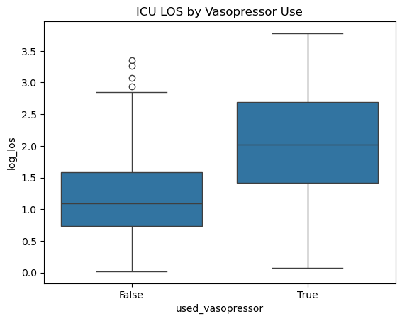

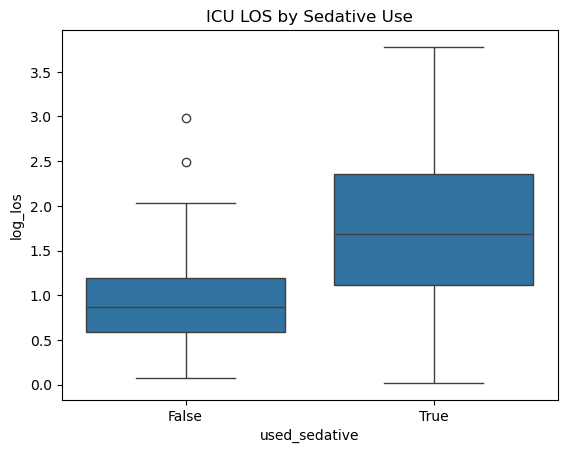

```python
import seaborn as sns
import matplotlib.pyplot as plt

# Boxplot: Vasopressor
sns.boxplot(data=final_df, x="used_vasopressor", y="log_los")
plt.title("ICU LOS by Vasopressor Use")
plt.show()

# Boxplot: Sedative
sns.boxplot(data=final_df, x="used_sedative", y="log_los")
plt.title("ICU LOS by Sedative Use")
plt.show()
```

```python
from scipy.stats import ttest_ind

# Vasopressor
t1 = ttest_ind(
    final_df[final_df["used_vasopressor"] == True]["log_los"],
    final_df[final_df["used_vasopressor"] == False]["log_los"],
    equal_var=False
)

# Sedative
t2 = ttest_ind(
    final_df[final_df["used_sedative"] == True]["log_los"],
    final_df[final_df["used_sedative"] == False]["log_los"],
    equal_var=False
)

print(f"Vasopressor t={t1.statistic:.2f}, p={t1.pvalue:.4f}")
print(f"Sedative t={t2.statistic:.2f}, p={t2.pvalue:.4f}")
```

```
Vasopressor t=7.02, p=0.0000
Sedative t=6.54, p=0.0000
```

#### Boxplot: ICU LOS by Vasopressor Use

The first boxplot compares ICU Length of Stay (log-transformed) between patients who received vasopressors and those who did not.  
Patients who received vasopressors showed a higher median and wider distribution of ICU LOS.

#### Boxplot: ICU LOS by Sedative Use

The second boxplot compares patients who received sedatives.  
Again, sedative use is associated with a visibly higher ICU LOS distribution.

### T-Test: Do Medications Significantly Affect ICU LOS?

We conducted independent two-sample t-tests comparing log(LOS) between groups.

These p-values indicate that both medication types significantly increase ICU LOS.

### Step 7: Multivariate Linear Regression Analysis

#### Regression Model Summary

We fit an Ordinary Least Squares (OLS) regression model with the log-transformed ICU length of stay (`log_los`) as the outcome variable, and the binary indicators for vasopressor and sedative use as predictors.

```python
import statsmodels.formula.api as smf

model = smf.ols("log_los ~ used_vasopressor + used_sedative", data=final_df).fit()
print(model.summary())
```

```
                            OLS Regression Results
==============================================================================
Dep. Variable:                log_los   R-squared:                       0.262
Model:                            OLS   Adj. R-squared:                  0.255
Method:                 Least Squares   F-statistic:                     38.36
Date:                Fri, 11 Apr 2025   Prob (F-statistic):           5.56e-15
Time:                        02:37:22   Log-Likelihood:                -246.63
No. Observations:                 219   AIC:                             499.3
Df Residuals:                     216   BIC:                             509.4
Df Model:                           2
Covariance Type:            nonrobust
============================================================================================
                               coef    std err          t      P>|t|      [0.025      0.975]
--------------------------------------------------------------------------------------------
Intercept                    0.7124      0.130      5.464      0.000       0.455       0.969
used_vasopressor[T.True]     0.6750      0.103      6.562      0.000       0.472       0.878
used_sedative[T.True]        0.6703      0.137      4.906      0.000       0.401       0.940
==============================================================================
Omnibus:                        1.043   Durbin-Watson:                   2.008
Prob(Omnibus):                  0.594   Jarque-Bera (JB):                0.985
Skew:                           0.163   Prob(JB):                        0.611
Kurtosis:                       2.968   Cond. No.                         5.14
==============================================================================

Notes:
[1] Standard Errors assume that the covariance matrix of the errors is correctly specified.
```

#### Interpretation :

Both vasopressor and sedative use are independently associated with longer ICU LOS, even when controlling for each other. This suggests that these medications could reflect underlying severity of illness, which affects the length of ICU stay.

### Step 8: Residual Diagnostics

To assess the validity of our linear regression assumptions, we conducted diagnostic checks on the residuals.

- The **Residuals vs Fitted Plot** helps detect non-linearity or heteroscedasticity.  
  We observe that the residuals are roughly centered around zero, suggesting linearity, but some funneling may indicate mild heteroscedasticity.
- The **Q-Q Plot** assesses the normality of residuals.  
  Points largely follow the 45-degree line, supporting the normality assumption.

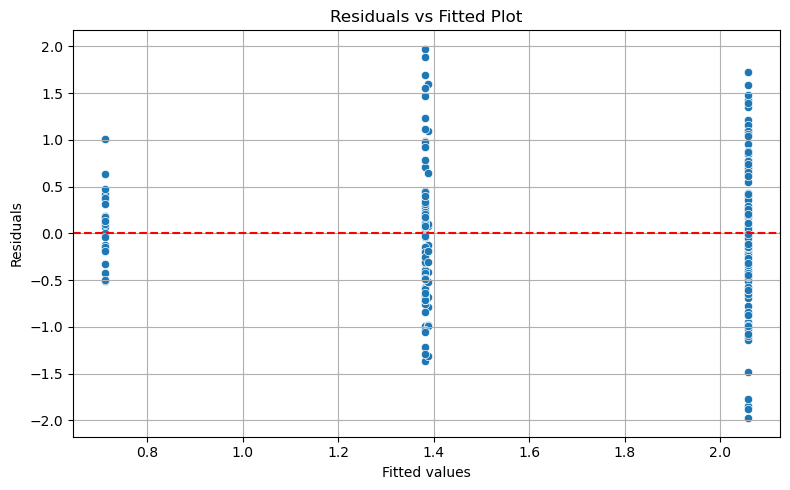

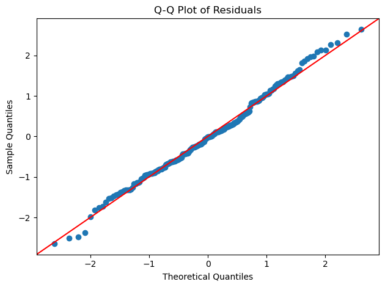

```python
import statsmodels.api as sm
import matplotlib.pyplot as plt
import seaborn as sns

fitted_vals = model.fittedvalues
residuals = model.resid

#  Residuals vs Fitted Plot
plt.figure(figsize=(8, 5))
sns.scatterplot(x=fitted_vals, y=residuals)
plt.axhline(0, color='red', linestyle='--')
plt.xlabel("Fitted values")
plt.ylabel("Residuals")
plt.title("Residuals vs Fitted Plot")
plt.grid(True)
plt.tight_layout()
plt.show()

#  Q-Q Plot for Normality
sm.qqplot(residuals, line='45', fit=True)
plt.title("Q-Q Plot of Residuals")
plt.tight_layout()
plt.show()
```

### Residuals vs Fitted Plot Interpretation

This plot is used to examine the assumptions of linearity and homoscedasticity.

### Q-Q Plot Interpretation

This plot checks whether the residuals follow a normal distribution.

- The points lie approximately along the 45-degree reference line, which indicates **normality of residuals**.
- This validates the **normality assumption** needed for valid p-values and confidence intervals in linear regression.

### Step 9: Final Summary & Interpretation

#### Summary of Findings

- Both **vasopressor** and **sedative** use were significantly associated with longer ICU stays (`log_los`), according to:
  - **T-tests**: Both p-values < 0.0001 indicate strong evidence of difference in log(LOS) between groups.
  - **OLS Regression**: The coefficients for both `used_vasopressor` and `used_sedative` were statistically significant (p < 0.001), suggesting a **positive association** with ICU LOS.

#### Conclusion

This analysis supports the hypothesis that **vasopressor and sedative use are associated with longer ICU stays** among SCI patients.  
However, the low R-squared suggests that other clinical variables (e.g., severity scores, comorbidities, vitals) not captured in this dataset may also play important roles.